# Проект. Исследование рынка инвестиций

Автор: Котов Алексей (когорта da_132)

Почта: alexkotov1001@yandex.ru

## Введение

Финансовая компания, работающая с венчурными инвестициями, хочет понять закономерности финансирования стартапов и оценить перспективы выхода на рынок с покупкой и развитием компаний. Для этого необходимо провести исследование на исторических данных.

Предстоить работать с информацией о компаниях, объёмах и типах привлечённых инвестиций, а также с дополнительной статистикой по возвратам средств.

Цель:

Подготовить датасет к работе, исследовать динамику и структуру финансирования стартапов и ответить на вопросы, важные для оценки инвестиционных стратегий.

Задачи:

- Проанализировать динамику предоставления финансирования по годам.
- Проанализировать динамику размера общего финансирования по массовым сегментам рынка для растущих в 2014 году сегментов.
- Проанализировать годовую динамику доли возвращённых средств по типам финансирования.
- Подготовить итоговый вывод и рекомендации заказчику.

## Шаг 1. Знакомство с данными: загрузка и предобработка

### Описание датасетов

Датасет получен из базы данных стартапов.

Название основного датасета — `cb_investments.zip`. Внутри архива один файл — `cb_investments.csv`.

Название дополнительного датасета — `cb_returns.csv`. Он содержит суммы возвратов по типам финансирования в миллионах долларов по годам.

### Вывод общей информации

Загружаем необходимые для работы библиотеки.

```python
# Импортируем библиотеки
import pandas as pd
import matplotlib.pyplot as plt
import seaborn as sns
```

```python
# Установим настройку, чтобы показывались все столбцы датафрейма
pd.set_option("display.max_columns", None)
```

Загружаем все данные по проекту.

```python
# датафрейм основного датасета с затратами на финансирование
df = pd.read_csv(".../cb_investments.zip", sep=';', low_memory=False)

# датафрейм вспомогательного датасета с суммами возвратов от финансирования
df_returns = pd.read_csv(".../cb_returns.csv")
```

Выводим информацию, которая необходима для принятия решений о предобработке.

```python
df.head()
```

|  | name | homepage_url | category_list | market | funding_total_usd | status | country_code | state_code | region | city | funding_rounds | participants | founded_at | founded_month | founded_quarter | founded_year | first_funding_at | mid_funding_at | last_funding_at | seed | venture | equity_crowdfunding | undisclosed | convertible_note | debt_financing | angel | grant | private_equity | post_ipo_equity | … |
| --- | --- | --- | --- | --- | --- | --- | --- | --- | --- | --- | --- | --- | --- | --- | --- | --- | --- | --- | --- | --- | --- | --- | --- | --- | --- | --- | --- | --- | --- | --- |
| 0 | Harvard University | http://harvard.edu | \|Education\| | Education | 9,00,00,000 | operating | USA | MA | Boston | Cambridge | 1.0 | NaN | 1636-09-08 | NaN | NaN | 1636.0 | 2014-01-06 | NaN | 2014-01-06 | 0.0 | 0.0 | 0.0 | 0.0 | 0.0 | 0.0 | 0.0 | 90000000.0 | 0.0 | 0.0 | … |
| 1 | University of New Brunswick | http://www.unb.ca | NaN | NaN | 20,00,000 | operating | NaN | NaN | NaN | NaN | 1.0 | NaN | 1785-01-01 | NaN | NaN | 1785.0 | 2014-05-15 | NaN | 2014-05-15 | 0.0 | 2000000.0 | 0.0 | 0.0 | 0.0 | 0.0 | 0.0 | 0.0 | 0.0 | 0.0 | … |
| 2 | DuPont | http://www.dupont.com | \|Business Services\|Agriculture\|Automotive\|Inve... | Business Services | 90,00,000 | operating | USA | DE | Wilmington, Delaware | Wilmington | 1.0 | 1.0 | 1802-07-19 | NaN | NaN | 1802.0 | 2009-07-02 | 2009-07-02 | 2009-07-02 | 0.0 | 9000000.0 | 0.0 | 0.0 | 0.0 | 0.0 | 0.0 | 0.0 | 0.0 | 0.0 | … |
| 3 | University of Michigan | http://www.umich.edu/ | \|Education\| | Education | 77,00,000 | operating | USA | MI | Detroit | Ann Arbor | 3.0 | 0.0 | 1817-01-01 | NaN | NaN | 1817.0 | 2013-11-21 | 2013-11-21 | 2014-11-03 | 0.0 | 0.0 | 0.0 | 1600000.0 | 0.0 | 0.0 | 0.0 | 6100000.0 | 0.0 | 0.0 | … |
| 4 | Case Western Reserve University | http://www.case.edu | \|Education\| | Education | 5,40,000 | operating | USA | OH | Cleveland | Cleveland | 1.0 | NaN | 1826-01-01 | NaN | NaN | 1826.0 | 2014-01-14 | NaN | 2014-01-14 | 0.0 | 0.0 | 0.0 | 0.0 | 0.0 | 0.0 | 0.0 | 540000.0 | 0.0 | 0.0 | … |

```python
df.info()
```

```
<class 'pandas.core.frame.DataFrame'>
RangeIndex: 54294 entries, 0 to 54293
Data columns (total 40 columns):
 #   Column                Non-Null Count  Dtype
---  ------                --------------  -----
 0   name                  49437 non-null  object
 1   homepage_url          45989 non-null  object
 2   category_list         45477 non-null  object
 3    market               45477 non-null  object
 4    funding_total_usd    49438 non-null  object
 5   status                48124 non-null  object
 6   country_code          44165 non-null  object
 7   state_code            30161 non-null  object
 8   region                44165 non-null  object
 9   city                  43322 non-null  object
```

[output cut: 32 more lines]

```python
# Процент пропусков каждого столбца
df.isna().mean().sort_values(ascending=False) * 100
```

```
state_code              44.448742
mid_funding_at          44.214830
participants            43.874093
founded_month           29.122923
founded_quarter         29.122923
founded_at              28.990312
founded_year            28.990312
city                    20.208494
country_code            18.655837
region                  18.655837
category_list           16.239363
 market                 16.239363
homepage_url            15.296350
status                  11.364055
name                     8.945740
private_equity           8.943898
round_E                  8.943898
round_F                  8.943898
round_D                  8.943898
round_C                  8.943898
round_G                  8.943898
round_B                  8.943898
round_A                  8.943898
product_crowdfunding     8.943898
secondary_market         8.943898
post_ipo_debt            8.943898
post_ipo_equity          8.943898
venture                  8.943898
grant                    8.943898
angel                    8.943898
debt_financing           8.943898
convertible_note         8.943898
undisclosed              8.943898
equity_crowdfunding      8.943898
seed                     8.943898
last_funding_at          8.943898
first_funding_at         8.943898
funding_rounds           8.943898
 funding_total_usd       8.943898
round_H                  8.943898
dtype: float64
```

В датафрейме `df` 40 столбцов и 54294 строк.

В названии столбцов `market` и `funding_total_usd` есть лишние пробелы.

Столбец `funding_total_usd` имеет тип `object` из-за некорректной записи чисел.

Столбцы `founded_at`, `founded_month`, `founded_quarter`, `first_funding_at`, `mid_funding_at` и `last_funding_at` типа `object`, но содержат информацию о дате.

В числовых столбцах можно попробовать оптимизировать размерность.

Больше всего пропусков в столбцах `state_code` (44%), `mid_funding_at` (44%) и `participants` (43%). Большинство пропусков в регистрационной информации о компаниях, которая для данного анализа не важна.

```python
df_returns.head()
```

|  | year | seed | venture | equity_crowdfunding | undisclosed | convertible_note | debt_financing | angel | grant | private_equity | post_ipo_equity | post_ipo_debt | secondary_market | product_crowdfunding |
| --- | --- | --- | --- | --- | --- | --- | --- | --- | --- | --- | --- | --- | --- | --- |
| 0 | 2000 | 16.70 | 55.40 | 0.0 | 78.21 | 0.00 | 8.66 | 6.43 | 0.0 | 0.00 | 0.94 | 0.0 | 0.20 | 0.0 |
| 1 | 2001 | 2.88 | 23.49 | 0.0 | 21.50 | 0.01 | 4.49 | 1.18 | 0.0 | 0.00 | 0.46 | 0.0 | 0.46 | 0.0 |
| 2 | 2002 | 6.59 | 209.42 | 0.0 | 25.77 | 0.02 | 3.42 | 3.41 | 0.0 | 1.51 | 0.34 | 0.0 | 0.06 | 0.0 |
| 3 | 2003 | 7.74 | 233.86 | 0.0 | 9.40 | 0.01 | 1.09 | 3.41 | 0.0 | 1.62 | 2.11 | 0.0 | 0.08 | 0.0 |
| 4 | 2004 | 9.93 | 555.90 | 0.0 | 33.19 | 0.01 | 13.55 | 9.18 | 0.0 | 2.19 | 3.38 | 0.0 | 0.55 | 0.0 |

```python
df_returns.info()
```

```
<class 'pandas.core.frame.DataFrame'>
RangeIndex: 15 entries, 0 to 14
Data columns (total 14 columns):
 #   Column                Non-Null Count  Dtype
---  ------                --------------  -----
 0   year                  15 non-null     int64
 1   seed                  15 non-null     float64
 2   venture               15 non-null     float64
 3   equity_crowdfunding   15 non-null     float64
 4   undisclosed           15 non-null     float64
 5   convertible_note      15 non-null     float64
 6   debt_financing        15 non-null     float64
 7   angel                 15 non-null     float64
 8   grant                 15 non-null     float64
 9   private_equity        15 non-null     float64
 10  post_ipo_equity       15 non-null     float64
 11  post_ipo_debt         15 non-null     float64
 12  secondary_market      15 non-null     float64
 13  product_crowdfunding  15 non-null     float64
dtypes: float64(13), int64(1)
memory usage: 1.8 KB
```

В датафрейме `df_returns` с суммами возвратов от финансирования 14 столбцов и 15 строк.

Все столбцы имеют числовой тип соотвествтующий содержимому, но можно попробовать понизить размерность данных. Пропусков в данных датафрейма нет.

Данные соответствуют описанию.

### Предобработка данных

В названиях столбцов в датафрейма `df` есть столбцы с лишними пробелами в названии, приведем их к единому аккуратному стилю.

```python
# В датафрейме уберем лишние пробелы в названии столбцов
df.columns = df.columns.str.strip()
# В датафрейме все буквы в нижний регистр
df.columns = df.columns.str.lower()
# Выведем названия столбцов
df.columns
```

```
Index(['name', 'homepage_url', 'category_list', 'market', 'funding_total_usd',
       'status', 'country_code', 'state_code', 'region', 'city',
       'funding_rounds', 'participants', 'founded_at', 'founded_month',
       'founded_quarter', 'founded_year', 'first_funding_at', 'mid_funding_at',
       'last_funding_at', 'seed', 'venture', 'equity_crowdfunding',
       'undisclosed', 'convertible_note', 'debt_financing', 'angel', 'grant',
       'private_equity', 'post_ipo_equity', 'post_ipo_debt',
       'secondary_market', 'product_crowdfunding', 'round_a', 'round_b',
       'round_c', 'round_d', 'round_e', 'round_f', 'round_g', 'round_h'],
      dtype='object')
```

Уберем в столбце `funding_total_usd` выделение разрядов и приведите его к числовому типу, с заменой нечисловых значений на NaN.

```python
# Удаляем запятые
df['funding_total_usd'] = df['funding_total_usd'].str.replace(',', '')
# Приводим к числовому типу с заменой нечисловых значений на NaN
df['funding_total_usd'] = pd.to_numeric(df['funding_total_usd'], errors='coerce')
# Выводим первые строки для проверки
df['funding_total_usd'].head()
```

```
0    90000000.0
1     2000000.0
2     9000000.0
3     7700000.0
4      540000.0
Name: funding_total_usd, dtype: float64
```

Обработаем типы данных в столбцах `founded_at`, `founded_month`, `founded_quarter`, `first_funding_at`, `mid_funding_at` и `last_funding_at`, которые хранят значения даты и времени.

```python
# Список столбцов с датами
date_columns = ['founded_at', 'founded_month', 'founded_quarter', 'first_funding_at', 'mid_funding_at', 'last_funding_at']
# Выведем типы столбцов
print(df[date_columns].dtypes)
# Выведем первые столбцы с непустыми датами
df[date_columns].dropna().head()
```

```
founded_at          object
founded_month       object
founded_quarter     object
first_funding_at    object
mid_funding_at      object
last_funding_at     object
dtype: object
```

|  | founded_at | founded_month | founded_quarter | first_funding_at | mid_funding_at | last_funding_at |
| --- | --- | --- | --- | --- | --- | --- |
| 74 | 1903-01-01 | 1903-01 | 1903-Q1 | 2008-08-07 | 2008-08-07 | 2008-08-07 |
| 77 | 1906-01-01 | 1906-01 | 1906-Q1 | 2012-03-15 | 2012-03-15 | 2012-03-15 |
| 78 | 1906-01-01 | 1906-01 | 1906-Q1 | 2012-08-16 | 2012-08-16 | 2012-08-16 |
| 82 | 1908-01-01 | 1908-01 | 1908-Q1 | 2013-08-25 | 2013-08-25 | 2014-02-21 |
| 84 | 1910-01-01 | 1910-01 | 1910-Q1 | 2013-04-01 | 2013-04-01 | 2013-04-01 |

```python
# Приводим к типу даты и времени, используя определенный формат
for col in date_columns:
    if col in ['founded_at', 'first_funding_at', 'mid_funding_at', 'last_funding_at']:
        df[col] = pd.to_datetime(df[col], format='%Y-%m-%d', errors='coerce')
    elif col == 'founded_month':
        df[col] = pd.to_datetime(df[col], format='%Y-%m', errors='coerce')
    elif col == 'founded_quarter':
        df[col] = pd.PeriodIndex(df[col], freq='Q').to_timestamp()
    else:
        pass
# Выведем типы столбцов
print(df[date_columns].dtypes)
# Выведем первые столбцы с датами
df[date_columns].head()
```

```
founded_at          datetime64[ns]
founded_month       datetime64[ns]
founded_quarter     datetime64[ns]
first_funding_at    datetime64[ns]
mid_funding_at      datetime64[ns]
last_funding_at     datetime64[ns]
dtype: object
```

|  | founded_at | founded_month | founded_quarter | first_funding_at | mid_funding_at | last_funding_at |
| --- | --- | --- | --- | --- | --- | --- |
| 0 | NaT | NaT | NaT | 2014-01-06 | NaT | 2014-01-06 |
| 1 | 1785-01-01 | NaT | NaT | 2014-05-15 | NaT | 2014-05-15 |
| 2 | 1802-07-19 | NaT | NaT | 2009-07-02 | 2009-07-02 | 2009-07-02 |
| 3 | 1817-01-01 | NaT | NaT | 2013-11-21 | 2013-11-21 | 2014-11-03 |
| 4 | 1826-01-01 | NaT | NaT | 2014-01-14 | NaT | 2014-01-14 |

Для датасета `cb_returns` в датафрейме `df_returns` сделаем столбец `year` индексом.

```python
# В датафрейме сделаем столбец year индексом
df_returns.set_index('year', inplace=True)
# Выводим первые строки
df_returns.head()
```

| year | seed | venture | equity_crowdfunding | undisclosed | convertible_note | debt_financing | angel | grant | private_equity | post_ipo_equity | post_ipo_debt | secondary_market | product_crowdfunding |
| --- | --- | --- | --- | --- | --- | --- | --- | --- | --- | --- | --- | --- | --- |
| 2000 | 16.70 | 55.40 | 0.0 | 78.21 | 0.00 | 8.66 | 6.43 | 0.0 | 0.00 | 0.94 | 0.0 | 0.20 | 0.0 |
| 2001 | 2.88 | 23.49 | 0.0 | 21.50 | 0.01 | 4.49 | 1.18 | 0.0 | 0.00 | 0.46 | 0.0 | 0.46 | 0.0 |
| 2002 | 6.59 | 209.42 | 0.0 | 25.77 | 0.02 | 3.42 | 3.41 | 0.0 | 1.51 | 0.34 | 0.0 | 0.06 | 0.0 |
| 2003 | 7.74 | 233.86 | 0.0 | 9.40 | 0.01 | 1.09 | 3.41 | 0.0 | 1.62 | 2.11 | 0.0 | 0.08 | 0.0 |
| 2004 | 9.93 | 555.90 | 0.0 | 33.19 | 0.01 | 13.55 | 9.18 | 0.0 | 2.19 | 3.38 | 0.0 | 0.55 | 0.0 |

Обработаем текстовые данные. Пропуски в текстовых столбцах заполним заглушками `unknown`.

```python
columns_list = [] # список текстовых столбцов
for col in df.columns: # идем по всем столбцам
    if df[col].dtype == 'object': # условие, что текстовый столбец
        columns_list.append(col) # добавляем название столбца в список столбцов
        df[col] = df[col].str.strip() # удаление пробелов
        df[col] = df[col].str.lower() # в нижний регистр
        df[col] = df[col].fillna('unknown') # заполнение пропусков
print(f'Обработанные столбцы: {columns_list}')
# Выведем первые строки
df[columns_list].head()
```

```
Обработанные столбцы: ['name', 'homepage_url', 'category_list', 'market', 'status', 'country_code', 'state_code', 'region', 'city']
```

|  | name | homepage_url | category_list | market | status | country_code | state_code | region | city |
| --- | --- | --- | --- | --- | --- | --- | --- | --- | --- |
| 0 | harvard university | http://harvard.edu | \|education\| | education | operating | usa | ma | boston | cambridge |
| 1 | university of new brunswick | http://www.unb.ca | unknown | unknown | operating | unknown | unknown | unknown | unknown |
| 2 | dupont | http://www.dupont.com | \|business services\|agriculture\|automotive\|inve... | business services | operating | usa | de | wilmington, delaware | wilmington |
| 3 | university of michigan | http://www.umich.edu/ | \|education\| | education | operating | usa | mi | detroit | ann arbor |
| 4 | case western reserve university | http://www.case.edu | \|education\| | education | operating | usa | oh | cleveland | cleveland |

Обработаем полные дубликаты в данных и пропуски в `funding_total_usd`. Избавимся от тех строк, которые не несут какой-либо информации либо не содержат данных о финансировании.

```python
# Количество полных дубликатов
dub_count = df.duplicated().sum()
# Количество строк
rows_count = df.shape[0]
# Выводим количество и процент полных дубликатов
print(f'Полных дубликатов: {dub_count} из {rows_count} строк ({dub_count / rows_count * 100:.2f}%)')
# Удаляем дубликаты, сохраняя первый экземпляр
df.drop_duplicates(keep='first', inplace=True)
new_rows_count = df.shape[0]
# Выводим информацию после удаления дубликатов
print(f'Дубликаты удалены: осталось {new_rows_count} из {rows_count} строк ({new_rows_count / rows_count * 100:.2f}%)')
```

```
Полных дубликатов: 4855 из 54294 строк (8.94%)
Дубликаты удалены: осталось 49439 из 54294 строк (91.06%)
```

Создадим список столбцов `funding_columns`, содержащих инвестиции. Воспользуемся тем, что названия таких столбцов в двух датафреймов совпадают.

```python
# Создаем список столбцов с инвестициями
funding_columns = list(df_returns.columns)
# Выведем список
funding_columns
```

```
['seed',
 'venture',
 'equity_crowdfunding',
 'undisclosed',
 'convertible_note',
 'debt_financing',
 'angel',
 'grant',
 'private_equity',
 'post_ipo_equity',
 'post_ipo_debt',
 'secondary_market',
 'product_crowdfunding']
```

Найдем строки с пропусками или нулями в столбце `funding_total_usd`.

```python
# Создадим маску на условие пропусков или нулей
mask = df['funding_total_usd'].isna() | (df['funding_total_usd'] == 0)

# Результат проверки на пропуски или нули столбца funding_total_usd
print(f'Строк с пропусками или нулями в столбце "funding_total_usd" было: {mask.sum()}')
```

```
Строк с пропусками или нулями в столбце "funding_total_usd" было: 8532
```

Попробуем восстановить пропуски или нули суммой столбцов из списка `funding_columns` с отдельными инвестициями.

```python
# Присвоим пропускам или нулям сумму столбцов из списка funding_columns
df.loc[mask, 'funding_total_usd'] = df.loc[mask, funding_columns].sum(axis=1)

# Обновим маску на условие пропусков или нулей
mask = df['funding_total_usd'].isna() | (df['funding_total_usd'] == 0)

# Результат проверки на пропуски или нули столбца funding_total_usd
print(f'Строк с пропусками или нулями в столбце "funding_total_usd" стало: {df[mask].shape[0]}')
```

```
Строк с пропусками или нулями в столбце "funding_total_usd" стало: 8532
```

Получается, что строки с пропусками или нулями в поле `funding_columns` не получилось заполнить значениями, т. к. остальные столбцы с отдельными инвестициями тоже были пустые или нулевые. Данные строки не несут информации о финансировании, поэтому их можно удалить.

```python
# Выводим сколько строк было
rows_count = df.shape[0]
print(f'Было: {rows_count} строк')

# Удаляем строки с нулевым значением в столбце funding_total_usd
df = df[~mask]

# Выводим сколько строк стало
new_rows_count = df.shape[0]
print(f'Удалено: {rows_count - new_rows_count} ({(rows_count - new_rows_count) / rows_count * 100:.2f}%) строк')
print(f'Осталось: {new_rows_count} строк')
```

```
Было: 49439 строк
Удалено: 8532 (17.26%) строк
Осталось: 40907 строк
```

Удалили 8532 (17% от 49439) строк без данных о финансировании.

Заполним пропуски в значениях `mid_funding_at` на основании значений в столбцах `first_funding_at` и `last_funding_at`. В качестве нового значения вместо пропусков возьмем приблизительно середину интервала между этими двумя датами.

```python
# Сколько пропусков в поле mid_funding_at было
mask = df['mid_funding_at'].isna()
rows_count = mask.sum()
print(f'Пропусков в поле "mid_funding_at" было: {rows_count} ({rows_count / df.shape[0] * 100:.2f}% всех строк)')

# Заполняем пропуски с помощью значений first_funding_at и last_funding_at
diff_date = (df.loc[mask, 'last_funding_at'] - df.loc[mask, 'first_funding_at'])
df.loc[mask, 'mid_funding_at'] = df.loc[mask, 'first_funding_at'] + (diff_date // 2)

# Сколько пропусков в поле mid_funding_at стало
mask = df['mid_funding_at'].isna()
new_rows_count = mask.sum()
print(f'Пропусков в поле "mid_funding_at" стало: {new_rows_count}')

# Проверим незаполненные пустые
df.loc[mask, ['first_funding_at', 'mid_funding_at', 'last_funding_at']]
```

```
Пропусков в поле "mid_funding_at" было: 13676 (33.43% всех строк)
Пропусков в поле "mid_funding_at" стало: 1
```

|  | first_funding_at | mid_funding_at | last_funding_at |
| --- | --- | --- | --- |
| 33041 | NaT | NaT | 2014-09-25 |

Строки с пропусками в значениях `mid_funding_at` составляли треть всех строк. После заполнения пропусков остался только 1 пропуск, из-за того, что у этой записи пустое значение `first_funding_at`, присвоим `mid_funding_at` непустое значение `last_funding_at`.

```python
# Присвоим пустому mid_funding_at непустое значение last_funding_at.
df.loc[mask, 'mid_funding_at'] = df.loc[mask, 'last_funding_at']
# Проверим
df.loc[mask, ['first_funding_at', 'mid_funding_at', 'last_funding_at']]
```

|  | first_funding_at | mid_funding_at | last_funding_at |
| --- | --- | --- | --- |
| 33041 | NaT | 2014-09-25 | 2014-09-25 |

Результаты предобработки:

- В датафрейме `df` 40 столбцов и 54294 строк.
- В датафрейме `df_returns` с суммами возвратов от финансирования 14 столбцов и 15 строк.
- Нормализованы названия столбцов датафрейма `df`.
- Исправлены данные в столбце `funding_total_usd` и переведены в числовой тип.
- Данные с информацией о дате переведены в соответствующий тип.
- В датафрейме `df_returns` индексами сделали поле `year`.
- Нормализовали данные в текстовых столбцах. Пропуски в текстовых столбцах заполним заглушками `unknown`.
- Удалили 4855 полных дубликатов из 54294 строк (8.94%), осталось 49439 строк.
- Удалили 8532 строк (17% от 49439 строк) без данных о финансировании в столбце `funding_total_usd` и столбцах с отдельными инвестициями, осталось 40907 строк от начального количества.
- Строки с пропусками в значениях `mid_funding_at` составляли треть всех строк и успешно были заполнены по столбцам `first_funding_at` и `last_funding_at`.
- Итого из 54294 строк всего была удалена четверть - 13387 строк (24.7%). Оставшихся данных достаточно для анализа.

## Шаг 2. Инжиниринг признаков

### Группы по срокам финансирования

Разделим все компании на три группы:

- Единичное финансирование — был всего один раунд финансирования.
- Срок финансирования до года — между первым и последним раундом финансирования прошло не более года.
- Срок финансирования более года.

```python
# Создаем новый столбец с группой финансирования и присваиваем значение по умолчанию "более года"
df['funding_type'] = 'более года'
# Найдем группу "единичное"
df.loc[df['funding_rounds'] == 1, 'funding_type'] = 'единичное'
# Найдем группу "до года"
df.loc[(df['funding_rounds'] > 1) & ((df['last_funding_at'] - df['first_funding_at']) <= pd.Timedelta(days=365)), 'funding_type'] = 'до года'
```

Визуализируем соотношение этих групп, создав два графика:

- По количеству компаний: покажем, какой процент от общего числа компаний относится к каждой из трёх групп.
- По объёму инвестиций: отобразим, какую долю от общего объёма привлечённых средств получила каждая группа.

Для ясности и согласованности используем единую цветовую палитру для всех графиков, чтобы каждая категория всегда отображалась одним и тем же цветом.

```python
# Палитра: синий, оранжевый, зелёный
colors_list = colors = ['#377EB0', '#FF6F33', '#4CAF50']
# Порядок групп
category_order = ['единичное', 'до года', 'более года']

# Cчитаем и количество, и сумму инвестиций по категориям
df_agg = df.groupby('funding_type').agg(
    count=('funding_type', 'size'),                # количество компаний
    total_investment=('funding_total_usd', 'sum')  # сумма инвестиций
).reset_index()

# Рассчитываем доли в процентах
total_count = df_agg['count'].sum()
total_invest = df_agg['total_investment'].sum()
df_agg['percent_count'] = (df_agg['count'] / total_count) * 100
df_agg['percent_invest'] = (df_agg['total_investment'] / total_invest) * 100

# Сортируем датафрейм по нужному порядку категорий
df_agg = df_agg.set_index('funding_type').loc[category_order].reset_index()

# Выводим
df_agg
```

|  | funding_type | count | total_investment | percent_count | percent_invest |
| --- | --- | --- | --- | --- | --- |
| 0 | единичное | 24113 | 1.993044e+11 | 58.945902 | 30.618237 |
| 1 | до года | 4501 | 4.888598e+10 | 11.003007 | 7.510132 |
| 2 | более года | 12293 | 4.027433e+11 | 30.051092 | 61.871631 |

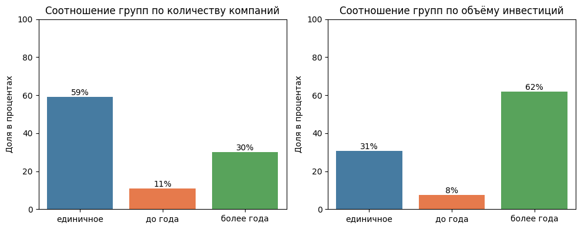

```python
# Создаём полотно с двумя подграфиками (2 графика по горизонтали)
fig, (ax1, ax2) = plt.subplots(1, 2, figsize=(10, 4))

# Первый график: Соотношение групп по количеству компаний
sns.barplot(
    data=df_agg,
    x='funding_type',
    y='percent_count',
    palette=colors_list,
    order=category_order,
    ax=ax1  # указываем ось для первого графика
)

# Добавляем подписи к первому графику
for idx, value in enumerate(df_agg['percent_count']):
    ax1.text(idx, value, f'{value:.0f}%', ha='center', va='bottom',)

# Оформление первого графика
ax1.set_title('Соотношение групп по количеству компаний')
ax1.set_ylabel('Доля в процентах')
ax1.set_xlabel('')
ax1.set_ylim(0, 100)

# Второй график: соотношение по объёму инвестиций
sns.barplot(
    data=df_agg,
    x='funding_type',
    y='percent_invest',
    palette=colors_list,
    order=category_order,
    ax=ax2  # указываем ось для второго графика
)

# Добавляем подписи ко второму графику
for idx, value in enumerate(df_agg['percent_invest']):
    ax2.text(idx, value, f'{value:.0f}%', ha='center', va='bottom')

# Оформление второго графика
ax2.set_title('Соотношение групп по объёму инвестиций')
ax2.set_ylabel('Доля в процентах')
ax2.set_xlabel('')
ax2.set_ylim(0, 100)

# Общая настройка и отображение
plt.tight_layout()
plt.show()
```

Распределение групп финансирования по количеству компаний / по объему инвестиций:

- Единичное - 59% / 31%.
- До года - 11% / 8%.
- Более года - 30% / 62%.

### Выделение средних и нишевых сегментов рынка

Компании указывают свой сегмент рынка в столбце `market`. Рассчитаем, как часто в датасете встречается каждый из сегментов. Сегменты, к которым относится более 120 компаний, отнесите к массовым, сегменты, в которые входит от 35 до 120 включительно, отнесите к средним, а сегменты до 35 компаний отнесите к нишевым.

```python
# Распределение количества компаний по сегменту
df_segment = df['market'].value_counts(ascending=False).reset_index()
df_segment.columns = ['market', 'count']
# Назначаем категории
df_segment['category'] = 'средний'
df_segment.loc[df_segment['count'] > 120, 'category'] = 'массовый'
df_segment.loc[df_segment['count'] < 35, 'category'] = 'нишевый'

# Рассчитаем, сколько сегментов попадает в каждую из категорий.
df_segment['category'].value_counts(ascending=False).reset_index()
```

|  | index | category |
| --- | --- | --- |
| 0 | нишевый | 289 |
| 1 | средний | 57 |
| 2 | массовый | 49 |

1. Нишевых сегментов - 289.
2. Средних сегментов - 57.
3. Массовых сегментов - 49.

Построим график распределения количества компаний в сегментах и отобразите на нём разделение на нишевые и средние сегменты.

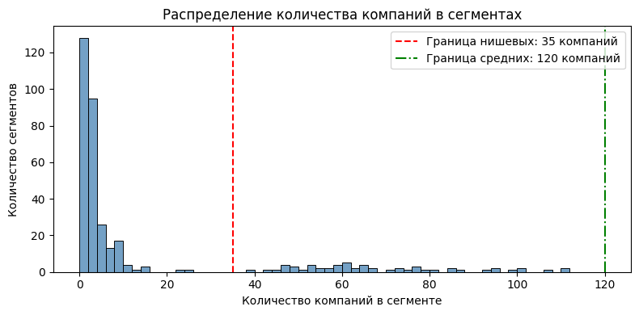

```python
# Размер графика
plt.figure(figsize=(8, 4))

# Гистограмма
ax = sns.histplot(
    data=df_segment['count'],
    bins=range(0,121,2),
    color='steelblue',
)

plt.axvline(35, color='r', linestyle='--', label='Граница нишевых: 35 компаний')
plt.axvline(120, color='g', linestyle='-.', label='Граница средних: 120 компаний')


# Оформление
plt.title('Распределение количества компаний в сегментах')
plt.ylabel('Количество сегментов')
plt.xlabel('Количество компаний в сегменте')
plt.legend()

# Отобразить график
plt.tight_layout()
plt.show()
```

Вывод: Подавляющее большинство сегментов - нишевые, содержащие до 5 компаний.

Оставим в столбце `market` только массовые сегменты. Для остальных сегментов заменим значения на заглушки — `niche` для нишевых и `mid` для средних.

Дальнейшие исследования выполним с учётом этой замены. Индивидуальные сегменты внутри средней и нишевой групп рассматривать не нужно — они объединяются в два общих сегмента.

```python
# создаем df_cor - копию датафрейма df с присоединением столбца category из датафрейма df_segment
df_corr = df.copy().merge(df_segment[['market', 'category']], on='market', how='left')
# замена средних сегментов
df_corr.loc[df_corr['category'] == 'средний', 'market'] = 'mid'
# замена нишевых сегментов
df_corr.loc[df_corr['category'] == 'нишевый', 'market'] = 'niche'
# выводим для проверки
df_corr[['market', 'category']]

# Рассчитаем, сколько компаний попадает в каждый сегмент
df_corr['market'].value_counts(ascending=False).reset_index()
```

|  | index | market |
| --- | --- | --- |
| 0 | software | 4812 |
| 1 | mid | 3841 |
| 2 | biotechnology | 3590 |
| 3 | unknown | 2503 |
| 4 | mobile | 2344 |
| 5 | e-commerce | 1866 |
| 6 | curated web | 1693 |
| 7 | enterprise software | 1381 |
| 8 | health care | 1185 |
| 9 | clean technology | 1180 |
| 10 | games | 1117 |
| 11 | advertising | 1107 |
| 12 | hardware + software | 1062 |
| 13 | social media | 1003 |
| 14 | health and wellness | 873 |
| 15 | education | 844 |
| 16 | niche | 830 |
| 17 | finance | 828 |
| 18 | analytics | 667 |
| 19 | manufacturing | 596 |
| 20 | security | 567 |
| 21 | semiconductors | 484 |
| 22 | web hosting | 424 |
| 23 | consulting | 349 |
| 24 | hospitality | 336 |
| 25 | travel | 330 |
| 26 | fashion | 303 |
| 27 | news | 301 |
| 28 | messaging | 295 |
| 29 | search | 291 |
| 30 | real estate | 279 |
| 31 | saas | 272 |
| 32 | music | 264 |
| 33 | internet | 241 |
| 34 | technology | 238 |
| 35 | apps | 223 |
| 36 | photography | 204 |
| 37 | sports | 204 |
| 38 | marketplaces | 196 |
| 39 | video | 188 |
| 40 | social network media | 158 |
| 41 | automotive | 155 |
| 42 | cloud computing | 152 |
| 43 | medical | 151 |
| 44 | entertainment | 150 |
| 45 | big data | 150 |
| 46 | networking | 143 |
| 47 | design | 135 |
| 48 | nonprofits | 135 |
| 49 | public relations | 134 |
| 50 | startups | 133 |

## Шаг 3. Работа с выбросами и анализ

### Анализируем и помечаем выбросы в каждом из сегментов

Заказчика интересует обычный для рассматриваемого периода размер средств, который предоставлялся компаниям.

По предобработанному столбцу `funding_total_usd` графическим образом оценим, какой размер общего финансирования для одной компании будет типичным, а какой — выбивающимся. Укажем интервал, в котором лежат типичные значения.

Для удобства в столбце `funding_total_usd` изменим единицы измерения с долларов на млн долларов.

```python
# В столбце `funding_total_usd` изменим единицы измерения с долларов на млн долларов
df_corr['funding_total_usd'] = df_corr['funding_total_usd'] / 1000000
```

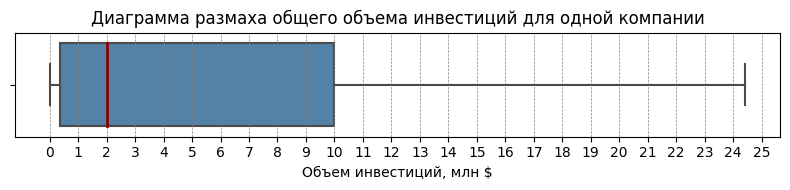

```python
# Размер графика
plt.figure(figsize=(8, 2))

# Диаграмма размаха
ax = sns.boxplot(
    data=df_corr,
    orient='h',
    x='funding_total_usd',
    showfliers=False,
    color='steelblue',
    medianprops={'color': 'darkred', 'linewidth': 2}
    )

# Оформление
plt.title('Диаграмма размаха общего объема инвестиций для одной компании')
plt.ylabel('')
plt.xlabel('Объем инвестиций, млн $')

# Добавляем метки с шагом 1
plt.xticks(range(0, 26, 1))
# Убираем научный формат
plt.ticklabel_format(axis='x', style='plain')
# Вертикальные линии сетки
ax.grid(axis='x', color='gray', linestyle='--', linewidth=0.5)

# Отобразить график
plt.tight_layout()
plt.show()
```

Вывод:

- По диаграмме размаха видно, что распеределение асимметричное правостороннее.
- Медиана около 2 млн USD.
- Типичные значения в пределах до 24.5 млн USD.

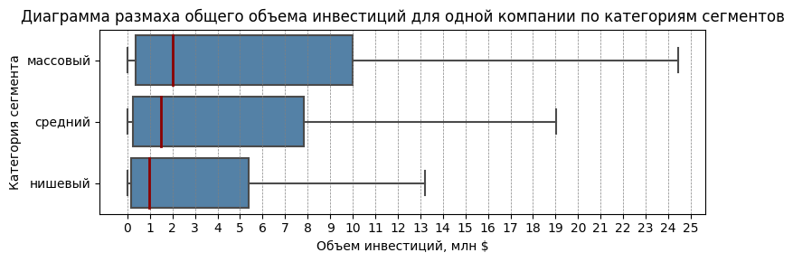

```python
# Размер графика
plt.figure(figsize=(8, 3))

# Диаграмма размаха
ax = sns.boxplot(
    data=df_corr,
    orient='h',
    x='funding_total_usd',
    y='category',
    showfliers=False,
    color='steelblue',
    medianprops={'color': 'darkred', 'linewidth': 2}
    )

# Оформление
plt.title('Диаграмма размаха общего объема инвестиций для одной компании по категориям сегментов')
plt.ylabel('Категория сегмента')
plt.xlabel('Объем инвестиций, млн $')

# Добавляем метки с шагом 1
plt.xticks(range(0, 26, 1))
# Убираем научный формат
plt.ticklabel_format(axis='x', style='plain')
# Вертикальные линии сетки
ax.grid(axis='x', color='gray', linestyle='--', linewidth=0.5)

# Отобразить график
plt.tight_layout()
plt.show()
```

Вывод:

- По диаграмме размаха по категориям сегментов видно, что у всех категорий также распеределение асимметричное правостороннее.
- Медиана у нишевых сегментов около 1 млн USD, у средних - 1.5 млн USD, у массовых - 2 млн USD.
- Предел типичных значений у нишевых сегментов до 13.2 млн USD, у средних - до 19 млн USD, у массовых - до 24.5 млн USD.

Определим компании с аномальным объёмом общего финансирования, используя метод IQR отдельно по каждому сегменту. Все нишевые сегменты были объединены в одну группу, а средние — в другую.

```python
# Создаем столбец-индикатор аномального значения
df_corr['anomaly'] = False
# Список уникальных названий сегментов
market_list = df_corr['market'].unique()

# Определяем компании с аномальным финансированием отдельно по каждому сегменту
for market in market_list:
    ser = df_corr.loc[df_corr['market'] == market, 'funding_total_usd']
    q_1 = ser.quantile(0.25)
    q_3 = ser.quantile(0.75)
    iqr = q_3 - q_1
    lower =  q_1 - 1.5 * iqr
    upper =  q_3 + 1.5 * iqr
    mask = (df_corr['market'] == market) & ((df_corr['funding_total_usd'] > upper) | (df_corr['funding_total_usd'] < lower))
    df_corr.loc[mask, 'anomaly'] = True

# Выведем количество компаний с аномальным финансированием
print(f'Количество компаний с аномальным финансированием: {df_corr["anomaly"].sum()} ({df_corr["anomaly"].sum() / df_corr.shape[0] * 100:.1f}%)')
print(f'Общее количество компаний в датафрейме: {df_corr.shape[0]}')
```

```
Количество компаний с аномальным финансированием: 5244 (12.8%)
Общее количество компаний в датафрейме: 40907
```

Компаний с аномальным финансированием: 5244 (12.8%) из 40907.

Определим сегменты рынка с наибольшей долей компаний, получивших аномальное финансирование, и выведем топ таких сегментов.

```python
# Группируем по сегменту и найдем долю аномальных компаний в процентах
df_grouped = df_corr.groupby('market')['anomaly'].mean() * 100
# Сортируем по убыванию доли аномальных и сбросим индексы
df_grouped = df_grouped.sort_values(ascending=False).reset_index()
df_grouped.columns = ['market', 'percent']
# Выведем топ-10
df_grouped.head(10)
```

|  | market | percent |
| --- | --- | --- |
| 0 | real estate | 17.204301 |
| 1 | entertainment | 16.666667 |
| 2 | consulting | 16.618911 |
| 3 | search | 16.494845 |
| 4 | cloud computing | 16.447368 |
| 5 | saas | 16.176471 |
| 6 | photography | 16.176471 |
| 7 | technology | 15.966387 |
| 8 | video | 15.957447 |
| 9 | niche | 15.903614 |

Топ-10 сегментов компаний с аномальным финансированием:

1. real estate - 17.2%
2. entertainment - 16.7%
3. consulting - 16.6%
4. search - 16.5%
5. cloud computing - 16.4%
6. saas - 16.2%
7. photography - 16.2%
8. technology - 16.0%
9. video - 16.0%
10. niche - 15.9%

### Определяем границы рассматриваемого периода, отбрасываем аномалии

Проверим по датасету, можно ли считать, что нам предоставили полные данные за 2014 год.

```python
# Оставим только даты последнего финансирования за 2014 год
df_last_date = df_corr.loc[df_corr['last_funding_at'].dt.year == 2014, 'last_funding_at']
# Подсчитаем количество последних финансирований в каждый день
df_last_date = df_last_date.value_counts().reset_index()
df_last_date.columns = ['last_funding_at', 'count']
# Отсортируем по дате
df_last_date = df_last_date.sort_values('last_funding_at')

df_last_date
```

|  | last_funding_at | count |
| --- | --- | --- |
| 0 | 2014-01-01 | 274 |
| 137 | 2014-01-02 | 41 |
| 241 | 2014-01-03 | 15 |
| 269 | 2014-01-04 | 7 |
| 258 | 2014-01-05 | 10 |
| ... | ... | ... |
| 332 | 2014-11-29 | 1 |
| 215 | 2014-12-01 | 26 |
| 225 | 2014-12-02 | 24 |
| 329 | 2014-12-24 | 1 |
| 331 | 2014-12-31 | 1 |

335 rows × 2 columns

```python
# Добавим столбец месяца 2014 года
df_last_date['last_funding_at'] = pd.to_datetime(df_last_date['last_funding_at'])
df_last_date['month'] = df_last_date['last_funding_at'].dt.month
# Подсчитаем количество последних финансирований по месяцам 2014 года
df_last_date.groupby('month')['count'].sum()
```

```
month
1     1178
2      947
3     1072
4     1077
5     1036
6     1229
7     1254
8     1064
9     1135
10    1139
11     732
12      52
Name: count, dtype: int64
```

Вывод:

- За 2014 год приведены данные, включающие 335 дней от 1 янв 2014 г. до 31 дек 2014 г.
- Отмечается заметное снижение финансирований в ноябре, а в декабре финансирований крайне мало (примерно в 20 раз меньше любого месяца с января по октябрь) - что указывает на потенциальную неполноту данных за конец 2014 г.

Исключим из датасета компании, которые ранее посчитали получившими аномальное финансирование.

```python
# Создает датафрейм без аномальных финансирований
df_clean = df_corr.loc[df_corr['anomaly'] == False].copy()
# Выведем количество строк
print(f'Строк было: {df_corr.shape[0]}')
print(f'Удалено аномальных финансирований: {df_corr.shape[0] - df_clean.shape[0]} ({(df_corr.shape[0] - df_clean.shape[0]) / df_corr.shape[0] * 100:.1f}%)')
print(f'Строк стало: {df_clean.shape[0]}')
```

```
Строк было: 40907
Удалено аномальных финансирований: 5244 (12.8%)
Строк стало: 35663
```

Из 40907 удалено 5244 (12.8%) компаний с аномальным финансированием, осталось 35663 компаний.

После исключения аномальных записей, на основе столбцов `mid_funding_at` и `funding_rounds` оставим в датасете данные только о компаниях, которые получали финансирование в годы, когда было зафиксировано 50 или более раундов финансирования.

```python
# Добавим новый столбец mid_funding_at_year с годом столбца mid_funding_at
df_clean['mid_funding_at_year'] = df_clean['mid_funding_at'].dt.year
# Выведем интересующие нас строки
df_clean[['mid_funding_at', 'mid_funding_at_year', 'funding_rounds']].head()
```

|  | mid_funding_at | mid_funding_at_year | funding_rounds |
| --- | --- | --- | --- |
| 1 | 2014-05-15 | 2014 | 1.0 |
| 2 | 2009-07-02 | 2009 | 1.0 |
| 3 | 2013-11-21 | 2013 | 3.0 |
| 4 | 2014-01-14 | 2014 | 1.0 |
| 7 | 2014-01-12 | 2014 | 1.0 |

```python
# Считаем количество раундов в год
rounds = df_clean['mid_funding_at_year'].value_counts().sort_index(ascending=False)

# Годы с 50 и более раундами
years = rounds[rounds >= 50].index.tolist()
print(f'Годы, когда было 50 и более раундов:', years)

# Фильтруем записи в годы с 50 и более раундами
df_filtered = df_clean.loc[df_clean['mid_funding_at_year'].isin(years)].copy()

# Выводим количество записей
print(f'Строк было: {df_clean.shape[0]}')
print(f'Строк отфильтровано: {(df_clean.shape[0] - df_filtered.shape[0])} ({(df_clean.shape[0] - df_filtered.shape[0]) / df_clean.shape[0] * 100:.1f}%)')
print(f'Строк стало: {df_filtered.shape[0]}')
```

```
Годы, когда было 50 и более раундов: [2014, 2013, 2012, 2011, 2010, 2009, 2008, 2007, 2006, 2005, 2004, 2003, 2000]
Строк было: 35663
Строк отфильтровано: 159 (0.4%)
Строк стало: 35504
```

### Анализ типов финансирования по объёму и популярности

Построим график, который покажет, какие типы финансирования в сумме привлекли больше всего денег. Переведем суммы инвестиций по различным типам финансирования в млн USD.

```python
# Сформируем список названий данных столбцов, заметив, что названия можно взять у другого датафрейм
funding_columns_list = df_returns.columns.tolist()
# Переведем суммы различных типов финансирования в млн USD
df_filtered[funding_columns_list] = df_filtered[funding_columns_list] / 1000000
```

```python
# Найдем сумму по каждому типу финансирования
df_total_funding = df_filtered[funding_columns_list].sum()

# Сбрасываем индексы
df_total_funding = df_total_funding.reset_index()

# Переименуем названия столбцов
df_total_funding.columns = ['funding_type', 'total_sum']

# Сортируем по убыванию
df_total_funding = df_total_funding.sort_values('total_sum', ascending=False).reset_index(drop=True)

# Суммы финансирования переведем в млн долларов
df_total_funding['total_sum'] = df_total_funding['total_sum']

# Выведем результат с форматированием
display(df_total_funding.style.format({'total_sum': '{:,.0f} млн $'}))
```

|  | funding_type | total_sum |
| --- | --- | --- |
| 0 | venture | 128,582 млн $ |
| 1 | seed | 9,420 млн $ |
| 2 | debt_financing | 8,157 млн $ |
| 3 | private_equity | 4,836 млн $ |
| 4 | angel | 2,477 млн $ |
| 5 | undisclosed | 2,021 млн $ |
| 6 | grant | 1,979 млн $ |
| 7 | post_ipo_equity | 1,946 млн $ |
| 8 | convertible_note | 565 млн $ |
| 9 | post_ipo_debt | 287 млн $ |
| 10 | equity_crowdfunding | 238 млн $ |
| 11 | product_crowdfunding | 186 млн $ |
| 12 | secondary_market | 45 млн $ |

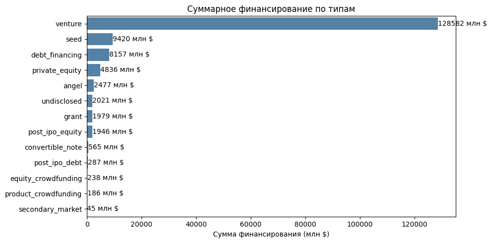

```python
# Строим стобчатую диаграмму
plt.figure(figsize=(10, 5))

ax = sns.barplot(
    data=df_total_funding,
    y='funding_type',
    x='total_sum',
    color='steelblue'
)

# Настраиваем оформление
plt.title('Суммарное финансирование по типам')
plt.xlabel('Сумма финансирования (млн $)')
plt.ylabel('')
# Добавляем подписи к столбцам
for idx, value in enumerate(df_total_funding['total_sum']):
    ax.text(value + 0.5, idx, f'{value:.0f} млн $', ha='left', va='center')

# Выводим график
plt.tight_layout()
plt.show()
```

Вывод:

- Венчурные инвестиции значительно превышают остальные вместе взятые.

Построим график без венчурных инвестиций.

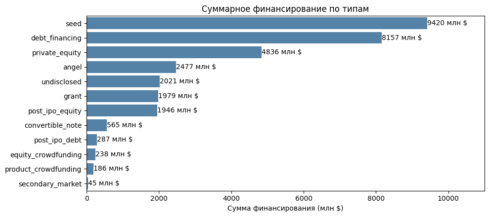

```python
# Строим стобчатую диаграмму
plt.figure(figsize=(10, 4.5))

ax = sns.barplot(
    data=df_total_funding[df_total_funding['funding_type'] != 'venture'],
    y='funding_type',
    x='total_sum',
    color='steelblue'
)

# Настраиваем оформление
plt.title('Суммарное финансирование по типам')
plt.xlabel('Сумма финансирования (млн $)')
plt.ylabel('')
plt.xlim(0, 11000)

# Добавляем подписи к столбцам
filtered_data = df_total_funding[df_total_funding['funding_type'] != 'venture'].reset_index(drop=True)
for idx, value in enumerate(filtered_data['total_sum']):
    ax.text(value + 0.5, idx, f'{value:.0f} млн $', ha='left', va='center')

# Выводим график
plt.tight_layout()
plt.show()
```

Также построим график, который покажет популярность разных типов финансирования — какие типы финансирования чаще всего используются компаниями, то есть встречаются в датасете наибольшее количество раз.

```python
# Найдем популярность каждого типа финансирования
df_popular = df_filtered[funding_columns_list].astype(bool).sum()

# Сбрасываем индексы
df_popular = df_popular.reset_index()

# Переименуем названия столбцов
df_popular.columns = ['funding_type', 'popular']

# Сортируем по убыванию
df_popular = df_popular.sort_values('popular', ascending=False).reset_index(drop=True)

# Выведем результат с форматированием
display(df_popular)
```

|  | funding_type | popular |
| --- | --- | --- |
| 0 | venture | 18762 |
| 1 | seed | 13358 |
| 2 | debt_financing | 3258 |
| 3 | angel | 2933 |
| 4 | grant | 1002 |
| 5 | undisclosed | 803 |
| 6 | private_equity | 633 |
| 7 | convertible_note | 520 |
| 8 | equity_crowdfunding | 515 |
| 9 | product_crowdfunding | 204 |
| 10 | post_ipo_equity | 163 |
| 11 | post_ipo_debt | 27 |
| 12 | secondary_market | 7 |

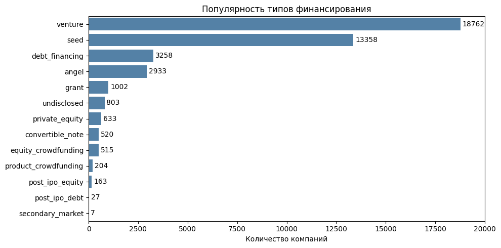

```python
# Строим стобчатую диаграмму
plt.figure(figsize=(10, 5))

ax = sns.barplot(
    data=df_popular,
    y='funding_type',
    x='popular',
    color='steelblue'
)

# Настраиваем оформление
plt.title('Популярность типов финансирования')
plt.xlabel('Количество компаний')
plt.ylabel('')
plt.xlim(0, 20000)
# Добавляем подписи к столбцам
for idx, value in enumerate(df_popular['popular']):
    ax.text(value + 100, idx, f'{value:.0f}', ha='left', va='center')

# Выводим график
plt.tight_layout()
plt.show()
```

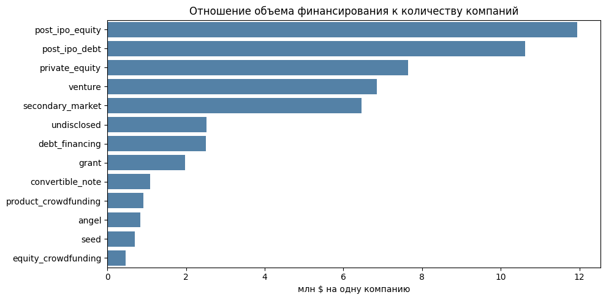

```python
# Соединим два датафрейма
df_analysis = df_total_funding.merge(df_popular, on='funding_type', how='inner')
# Среднее финансирование одной компании
df_analysis['avg_sum'] = df_analysis['total_sum'] / df_analysis['popular']
# Отсортируем
df_analysis = df_analysis.sort_values('avg_sum', ascending=False)

# Строим стобчатую диаграмму
plt.figure(figsize=(10, 5))

ax = sns.barplot(
    data=df_analysis,
    y='funding_type',
    x='avg_sum',
    color='steelblue'
)

# Настраиваем оформление
plt.title('Отношение объема финансирования к количеству компаний')
plt.xlabel('млн $ на одну компанию')
plt.ylabel('')

# Выводим график
plt.tight_layout()
plt.show()
```

Вывод:

- часто используемые типы финансирования, которые при этом характеризуются небольшими объёмами финансирования: `seed`, `angel`, `equity_crowdfunding`.
- редко используемые типы финансирования, которые при этом характеризуются значительным объёмом финансирования: `private_equity`, `post_ipo_equity`, `post_ipo_debt`.

Построим график суммарных объёмов возвратов от разных типов финансирования за весь период на основе дополнительного датасета.

```python
# Найдем сумму по каждому типу финансирования
df_returns_total = df_returns.sum()

# Сбрасываем индексы
df_returns_total = df_returns_total.reset_index()

# Переименуем названия столбцов
df_returns_total.columns = ['funding_type', 'total_sum_returns']

# Сортируем по убыванию
df_returns_total = df_returns_total.sort_values('total_sum_returns', ascending=False).reset_index(drop=True)

# Выведем результат с форматированием
display(df_returns_total.style.format({'total_sum_returns': '{:,.0f} млн $'}))
```

|  | funding_type | total_sum_returns |
| --- | --- | --- |
| 0 | venture | 40,579 млн $ |
| 1 | debt_financing | 4,735 млн $ |
| 2 | private_equity | 3,587 млн $ |
| 3 | seed | 2,382 млн $ |
| 4 | angel | 1,509 млн $ |
| 5 | post_ipo_equity | 1,105 млн $ |
| 6 | undisclosed | 731 млн $ |
| 7 | post_ipo_debt | 91 млн $ |
| 8 | convertible_note | 35 млн $ |
| 9 | secondary_market | 5 млн $ |
| 10 | equity_crowdfunding | 4 млн $ |
| 11 | product_crowdfunding | 2 млн $ |
| 12 | grant | 0 млн $ |

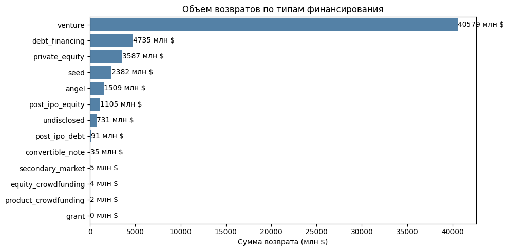

```python
# Строим стобчатую диаграмму
plt.figure(figsize=(10, 5))

ax = sns.barplot(
    data=df_returns_total,
    y='funding_type',
    x='total_sum_returns',
    color='steelblue'
)

# Настраиваем оформление
plt.title('Объем возвратов по типам финансирования')
plt.xlabel('Сумма возврата (млн $)')
plt.ylabel('')

# Добавляем подписи к столбцам
for idx, value in enumerate(df_returns_total['total_sum_returns']):
    ax.text(value + 0.5, idx, f'{value:.0f} млн $', ha='left', va='center')

# Выводим график
plt.tight_layout()
plt.show()
```

Вывод:

- Сумма возврата по венчурным инвестициям также превышает вместе взятые остальные типы финансирования.

Построим график без венчурных инвестиций.

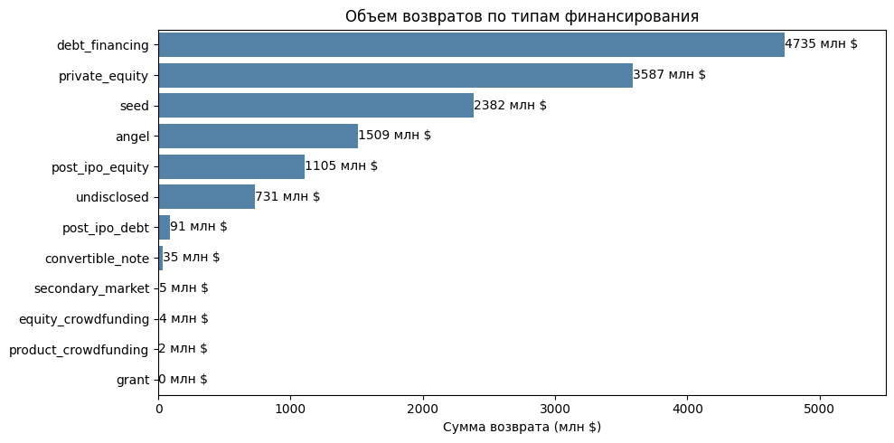

```python
# Строим стобчатую диаграмму
plt.figure(figsize=(10, 5))

ax = sns.barplot(
    data=df_returns_total[df_returns_total['funding_type'] != 'venture'],
    y='funding_type',
    x='total_sum_returns',
    color='steelblue'
)

# Настраиваем оформление
plt.title('Объем возвратов по типам финансирования')
plt.xlabel('Сумма возврата (млн $)')
plt.ylabel('')
plt.xlim(0, 5500)

# Добавляем подписи к столбцам
filtered_data = df_returns_total[df_returns_total['funding_type'] != 'venture']
for idx, value in enumerate(filtered_data['total_sum_returns']):
    ax.text(value + 0.5, idx, f'{value:.0f} млн $', ha='left', va='center')

# Выводим график
plt.tight_layout()
plt.show()
```

`venture` лидирует по объёму возвращённых средств, а вот находившийся в тройке лидеров и по объёму, и по количеству предоставленных средств `seed` перешёл на четвёртое место по возвратам.

## Шаг 4. Анализ динамики

### Динамика предоставления финансирования по годам

*Строим графики в этом задании и следующих, используя данные только по тем компаниям, которые остались в датасете после предыдущих фильтраций.*

Используя столбцы `funding_total_usd` и `funding_rounds`, рассчитаем для каждой компании средний объём одного раунда финансирования.

```python
# Добавим новый столбец со средним объемом одного раунда
df_filtered['avg_funding_round'] = df_filtered['funding_total_usd'] / df_filtered['funding_rounds']
# Выведем
df_filtered[['funding_total_usd', 'funding_rounds', 'avg_funding_round']].head()
```

|  | funding_total_usd | funding_rounds | avg_funding_round |
| --- | --- | --- | --- |
| 1 | 2.00 | 1.0 | 2.000000 |
| 2 | 9.00 | 1.0 | 9.000000 |
| 3 | 7.70 | 3.0 | 2.566667 |
| 4 | 0.54 | 1.0 | 0.540000 |
| 7 | 8.70 | 1.0 | 8.700000 |

Построим график, отражающий динамику типичного размера средств, которые стартапы получали в рамках одного раунда финансирования.

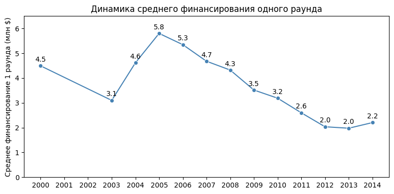

```python
# Сгруппируем по году mid_funding_at_year и найдем среднее финансирование одного раунда финансирования
df_agg = df_filtered.groupby('mid_funding_at_year')['avg_funding_round'].mean()
df_agg = df_agg.reset_index()
df_agg.columns = ['mid_funding_at_year', 'avg_funding_round']

# Размер графика
plt.figure(figsize=(8, 4))

# Строим диаграмму
ax = sns.lineplot(
    data=df_agg,
    x='mid_funding_at_year',
    y='avg_funding_round',
    marker='o',
    color='steelblue',
)
# Оформление
plt.ylabel('Среднее финансирование 1 раунда (млн $)')
plt.xlabel('')
plt.title('Динамика среднего финансирования одного раунда')
plt.ylim(0, 6.5)
plt.xticks(range(2000, 2015, 1))

# Добавляем подписи к каждой точке
for x, y in zip(df_agg['mid_funding_at_year'], df_agg['avg_funding_round']):
    plt.annotate(
        f'{y:.1f}',           # текст подписи
        xy=(x, y),         # координаты точки
        xytext=(0, 6),     # отступ от точки (8 пунктов вверх)
        textcoords='offset points',
        ha='center', # горизонтальное выравнивание: по центру точки
)

# Отображаем график
plt.tight_layout()
plt.show()
```

Построим график, отражающий динамику общего количества раундов за каждый год, то есть насколько активно происходили инвестиции на рынке (чем больше раундов, тем выше активность).

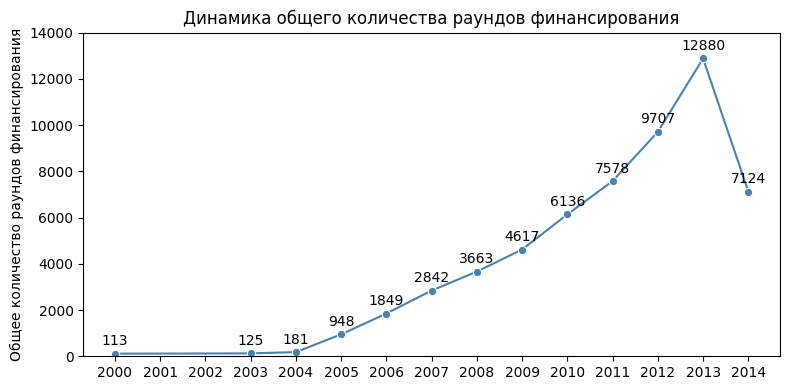

```python
# Сгруппируем по году mid_funding_at_year и найдем среднее финансирование одного раунда финансирования
df_agg = df_filtered.groupby('mid_funding_at_year')['funding_rounds'].sum()
df_agg = df_agg.reset_index()
df_agg.columns = ['mid_funding_at_year', 'funding_rounds']

# Размер графика
plt.figure(figsize=(8, 4))

# Строим диаграмму
ax = sns.lineplot(
    data=df_agg,
    x='mid_funding_at_year',
    y='funding_rounds',
    marker='o',
    color='steelblue',
)
# Оформление
plt.ylabel('Общее количество раундов финансирования')
plt.xlabel('')
plt.title('Динамика общего количества раундов финансирования')
plt.ylim(0, 14000)

plt.xticks(range(2000, 2015, 1))

# Добавляем подписи к каждой точке
for x, y in zip(df_agg['mid_funding_at_year'], df_agg['funding_rounds']):
    plt.annotate(
        f'{y:.0f}',           # текст подписи
        xy=(x, y),         # координаты точки
        xytext=(0, 6),     # отступ от точки (8 пунктов вверх)
        textcoords='offset points',
        ha='center', # горизонтальное выравнивание: по центру точки
)

# Отображаем график
plt.tight_layout()
plt.show()
```

Выводы:

- В 2005 году размер средств, собранных в рамках одного раунда, был максимальным (5.8 млн USD). После 2005 года размер средств на один раунд уменьшался, хотя количество раундов увеличивалось.
- В 2014 году размер средств на один раунд (2.2 млн USD) перестал уменьшаться после минимальных значений в 2012-2013 гг. (2.0 млн USD). При этом общее количество раундов финансирования с максимального количества 12 880 в 2013 г. резко уменьшилось до 7 124 в 2014 г. Но надо учитывать, что данные за декабрь 2014 года у нас неполные.
- Тенденция по типичному размеру финансирования в 2014 году - сохраняется на уровне двух предыдущих лет, но не хватает данных, чтобы утверждать, что закрепилась тенденция на увеличение среднего размера средств.

### Динамика размера общего финансирования по массовым сегментам рынка для растущих в 2014 году сегментов

Составим сводную таблицу, в которой указывается суммарный размер общего финансирования `funding_total_usd` по годам и сегментам рынка. Отберем из неё только те сегменты, которые показывали рост размера суммарного финансирования в 2014 году по сравнению с 2013.

На графике отразим, как менялся суммарный размер общего финансирования в каждом из отобранных сегментов по годам, за которые у нас достаточно данных. Рассматриваем только массовые сегменты, а средние и нишевые исключаем. Также с неизвестным сегментом тоже исключаем.

```python
# Найдем сумму общего финансирования отдельно по сегментам
df_market_table = df_filtered.pivot_table(
    index='market',
    columns='mid_funding_at_year',
    values='funding_total_usd',
    aggfunc='sum',
    fill_value=0
).drop(['mid', 'niche', 'unknown']) # исключаем средние и нишевые, а также неизвестные

# Оставим только те сегменты, где был рост в 2014 году относительно 2013 года
df_market_table = df_market_table[df_market_table[2014] > df_market_table[2013]]

# Выведем подходящие сегменты
df_market_table.index
```

```
Index(['apps', 'big data', 'design', 'internet', 'manufacturing', 'medical',
       'real estate', 'saas', 'startups', 'technology'],
      dtype='object', name='market')
```

Сегменты, показавшие рост суммарного финансирования в 2014 году относительно 2013: `apps`, `big data`, `design`, `internet`, `manufacturing`, `medical`, `real estate`, `saas`, `startups`, `technology`.

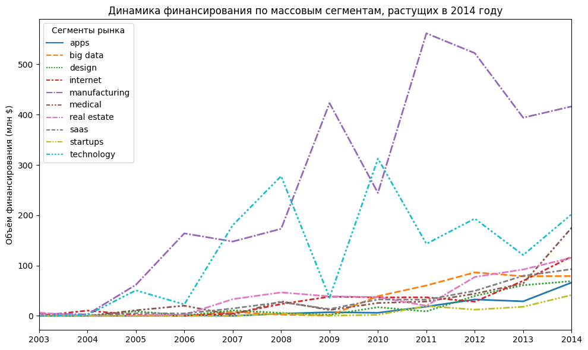

```python
# Строим линейный график
plt.figure(figsize=(10, 6))
ax = sns.lineplot(
    # Трнаспонируем таблицу для построения графиков
    data=df_market_table.T,
    linewidth=2,
)

# Оформление
plt.title('Динамика финансирования по массовым сегментам, растущих в 2014 году')
plt.ylabel('Объём финансирования (млн $)')
plt.xlabel('')
plt.xlim(2003, 2014) # Оставим данные с 2003 года, т. к. в 2001 и 2002 нет данных
plt.xticks(range(2003, 2015, 1))
plt.legend(title='Сегменты рынка', loc='upper left')

# Оптимизируем макет
plt.tight_layout()
# Показываем график
plt.show()
```

Слишком много сегментов, оставим только 6 сегментов, у которых самый большой относительный прирост объема финансирования в 2014 году относительно 2013 года.

```python
# Ищем разницу между 2014 годом и 2013 относительно 2013 года
df_top_segment = (df_market_table[2014] - df_market_table[2013]) / df_market_table[2013]
# Оставим топ-6 компаний
df_top_segment = df_top_segment.sort_values(ascending=False).head(6)
# Результат
df_top_segment
```

```
market
medical        1.718127
startups       1.295386
apps           1.294454
internet       0.689764
technology     0.671320
real estate    0.253338
dtype: float64
```

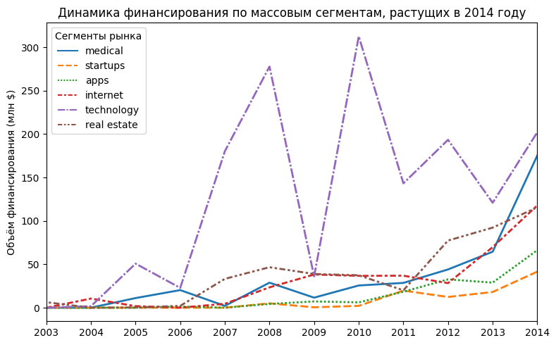

```python
# Строим линейный график
plt.figure(figsize=(8, 5))
ax = sns.lineplot(
    # Трнаспонируем таблицу для построения графиков
    data=df_market_table.loc[df_top_segment.index].T,
    linewidth=2,
)

# Оформление
plt.title('Динамика финансирования по массовым сегментам, растущих в 2014 году')
plt.ylabel('Объём финансирования (млн $)')
plt.xlabel('')
plt.xlim(2003, 2014) # Оставим данные с 2003 года, т. к. в 2001 и 2002 нет данных
plt.xticks(range(2003, 2015, 1))
plt.legend(title='Сегменты рынка', loc='upper left')

# Оптимизируем макет
plt.tight_layout()
# Показываем график
plt.show()
```

На основе графика сделайте вывод о том, какие сегменты показывают наиболее быстрый и уверенный рост. Выводы:

- Наиболее быстрый и уверенный рост в последние годы демонстрируют: `medical`, `internet`, `apps`, `real estate`.
- Стоит дополнительно отметить, что для технологического сегмента `technology` характерны самые большие объемы инвестиций, но и динамика волнообразная с самым большим размахом и периодическими резкими падениями.
- Видно смещение приоритетов инвесторов в сторону цифровых технологий и анализа данных.

### Годовая динамика доли возвращённых средств по типам финансирования

Заказчик хочет знать, какая часть вложенных или выданных денег со временем возвращается обратно инвесторам или финансистам.

Для каждого года и каждого вида финансирования рассчитаем нормированные значения возврата средств: какую долю возвращённые средства составляют от предоставленных. При этом слишком большие аномальные значения, то есть неадекватные выбросы, нужно заменить на пропуски.

```python
# Найдем сумму финансирования отдельно по типам финансирования
df_funding_table = df_filtered.pivot_table(
    index='mid_funding_at_year',
    values=funding_columns_list,
    aggfunc='sum',
    fill_value=0
)
# Название идекса поменяем
df_funding_table.index.name = 'year'
# Проверим, что получилось
df_funding_table
```

| year | angel | convertible_note | debt_financing | equity_crowdfunding | grant | post_ipo_debt | post_ipo_equity | private_equity | product_crowdfunding | secondary_market | seed | undisclosed | venture |
| --- | --- | --- | --- | --- | --- | --- | --- | --- | --- | --- | --- | --- | --- |
| 2000 | 24.086333 | 0.000000 | 14.000000 | 0.000000 | 0.293114 | 0.000000 | 3.467747 | 0.000000 | 0.000000 | 7.718867 | 16.759140 | 112.202640 | 327.962152 |
| 2003 | 5.629661 | 0.000000 | 1.050000 | 0.000000 | 16.850717 | 0.000000 | 0.000000 | 0.000000 | 0.000000 | 0.000000 | 15.318355 | 10.280000 | 372.234425 |
| 2004 | 11.013741 | 0.000000 | 30.816623 | 0.000000 | 10.363600 | 0.000000 | 0.000000 | 0.000000 | 0.000000 | 0.000000 | 18.104728 | 62.912359 | 664.150451 |
| 2005 | 60.914621 | 0.000000 | 101.720656 | 0.000000 | 6.266481 | 0.000000 | 4.796022 | 5.000000 | 0.000000 | 0.000000 | 39.425198 | 8.871332 | 4809.710779 |
| 2006 | 70.756153 | 10.702385 | 140.848395 | 0.933057 | 6.147500 | 0.000000 | 0.000000 | 17.820244 | 0.000000 | 0.000000 | 66.794774 | 61.545498 | 9020.604123 |
| 2007 | 201.152441 | 14.116788 | 208.601638 | 0.000000 | 34.237779 | 0.000000 | 12.000000 | 153.370229 | 0.000000 | 0.000000 | 192.296481 | 109.649902 | 12062.091399 |
| 2008 | 249.299613 | 28.600902 | 428.622061 | 0.000000 | 23.485347 | 0.000000 | 36.000000 | 191.756331 | 1.000000 | 0.000000 | 302.003020 | 119.920337 | 14234.730391 |
| 2009 | 157.822426 | 41.257969 | 1015.071410 | 2.049671 | 300.835487 | 0.000000 | 36.628903 | 258.118979 | 0.303050 | 19.300000 | 284.351394 | 99.687229 | 14755.360316 |
| 2010 | 245.725462 | 46.247821 | 1131.602620 | 7.400000 | 226.905678 | 0.000000 | 85.510500 | 524.927867 | 3.500000 | 0.910000 | 503.808937 | 210.408873 | 16595.510323 |
| 2011 | 393.511877 | 78.613209 | 1144.121986 | 3.091684 | 193.791434 | 3.100000 | 193.398404 | 910.997761 | 18.142441 | 12.500000 | 1166.553328 | 259.142865 | 15268.261295 |
| 2012 | 385.383621 | 105.770341 | 1375.685503 | 15.068930 | 154.094626 | 77.500000 | 199.703350 | 821.143538 | 13.136864 | 0.000000 | 1916.136879 | 449.964477 | 14970.428399 |
| 2013 | 417.044638 | 122.238088 | 1745.256931 | 46.383011 | 534.066826 | 44.800000 | 392.012155 | 1605.596587 | 82.289662 | 0.000000 | 2994.847714 | 311.937757 | 16230.161417 |
| 2014 | 254.923249 | 116.991933 | 819.616023 | 163.034292 | 471.410099 | 161.318349 | 982.634987 | 346.876968 | 67.721903 | 4.856929 | 1903.799080 | 204.908468 | 9270.842879 |

Удалим 2000 год в `df_funding_table`, т. к. нет данных за 2001 и 2002 года. Также удалим 2000, 2001 и 2002 года в `df_returns`.

```python
# Удалим 2000 год в df_funding_table
df_funding_table = df_funding_table.drop(2000)

# Удалим 2000-2002 гг в df_returns
df_returns = df_returns.drop([2000, 2001, 2002])
```

```python
# Посмотрим на возвраты
df_returns
```

| year | seed | venture | equity_crowdfunding | undisclosed | convertible_note | debt_financing | angel | grant | private_equity | post_ipo_equity | post_ipo_debt | secondary_market | product_crowdfunding |
| --- | --- | --- | --- | --- | --- | --- | --- | --- | --- | --- | --- | --- | --- |
| 2003 | 7.74 | 233.86 | 0.00 | 9.40 | 0.01 | 1.09 | 3.41 | 0.0 | 1.62 | 2.11 | 0.00 | 0.08 | 0.00 |
| 2004 | 9.93 | 555.90 | 0.00 | 33.19 | 0.01 | 13.55 | 9.18 | 0.0 | 2.19 | 3.38 | 0.00 | 0.55 | 0.00 |
| 2005 | 26.60 | 2628.92 | 0.00 | 9.51 | 0.02 | 35.09 | 31.06 | 0.0 | 2.40 | 3.51 | 0.00 | 0.05 | 0.00 |
| 2006 | 61.81 | 3100.18 | 0.19 | 46.74 | 1.78 | 113.21 | 47.75 | 0.0 | 16.67 | 20.58 | 0.00 | 0.12 | 0.00 |
| 2007 | 70.41 | 3585.37 | 0.01 | 55.37 | 3.22 | 125.68 | 164.51 | 0.0 | 88.81 | 24.36 | 0.00 | 0.57 | 0.00 |
| 2008 | 89.72 | 2717.02 | 0.03 | 41.02 | 1.71 | 397.54 | 102.83 | 0.0 | 130.38 | 84.28 | 0.00 | 0.47 | 0.00 |
| 2009 | 160.21 | 2501.29 | 0.18 | 37.50 | 2.25 | 394.10 | 97.21 | 0.0 | 203.70 | 76.76 | 0.00 | 0.12 | 0.02 |
| 2010 | 265.33 | 3299.35 | 0.39 | 52.15 | 3.14 | 503.73 | 157.21 | 0.0 | 339.08 | 115.72 | 0.00 | 0.18 | 0.24 |
| 2011 | 317.29 | 3919.38 | 0.30 | 59.36 | 3.96 | 572.92 | 172.17 | 0.0 | 666.03 | 129.01 | 3.04 | 0.16 | 0.26 |
| 2012 | 373.31 | 4727.74 | 0.44 | 71.04 | 4.79 | 694.97 | 193.03 | 0.0 | 762.40 | 160.88 | 20.34 | 0.34 | 0.28 |
| 2013 | 442.97 | 5749.29 | 1.14 | 84.40 | 6.00 | 848.65 | 225.87 | 0.0 | 988.53 | 219.93 | 30.45 | 0.81 | 0.34 |
| 2014 | 530.75 | 7272.01 | 1.15 | 105.72 | 7.87 | 1017.75 | 293.98 | 0.0 | 384.01 | 262.70 | 37.20 | 1.03 | 0.72 |

Разделим один датафрейм на другой, чтобы найти долю возвращенных средств. Долю выразим в процентах. При этом слишком большие аномальные значения, то есть неадекватные выбросы, нужно заменить на пропуски.

```python
# Находим долю возврата отдельно по каждому году и типу финансирование в процентах
df_funding_re_table = df_returns / (df_funding_table + 1e-60) * 100
# Cлишком большие аномальные значения более 10 000%, заменяем на пропуски
df_funding_re_table = df_funding_re_table.where(df_funding_re_table < 10000, float('nan'))
# Вывод
df_funding_re_table
```

| year | angel | convertible_note | debt_financing | equity_crowdfunding | grant | post_ipo_debt | post_ipo_equity | private_equity | product_crowdfunding | secondary_market | seed | undisclosed | venture |
| --- | --- | --- | --- | --- | --- | --- | --- | --- | --- | --- | --- | --- | --- |
| 2003 | 60.572031 | NaN | 103.809524 | 0.000000 | 0.0 | 0.000000 | NaN | NaN | 0.000000 | NaN | 50.527619 | 91.439689 | 62.826000 |
| 2004 | 83.350426 | NaN | 43.969776 | 0.000000 | 0.0 | 0.000000 | NaN | NaN | 0.000000 | NaN | 54.847551 | 52.755930 | 83.700914 |
| 2005 | 50.989400 | NaN | 34.496435 | 0.000000 | 0.0 | 0.000000 | 73.185653 | 48.000000 | 0.000000 | NaN | 67.469541 | 107.199235 | 54.658588 |
| 2006 | 67.485297 | 16.631807 | 80.377203 | 20.363172 | 0.0 | 0.000000 | NaN | 93.545296 | 0.000000 | NaN | 92.537180 | 75.943816 | 34.367765 |
| 2007 | 81.783745 | 22.809721 | 60.248808 | NaN | 0.0 | 0.000000 | 203.000000 | 57.905632 | 0.000000 | NaN | 36.615335 | 50.497081 | 29.724281 |
| 2008 | 41.247557 | 5.978832 | 92.748376 | NaN | 0.0 | 0.000000 | 234.111111 | 67.992540 | 0.000000 | NaN | 29.708312 | 34.206041 | 19.087260 |
| 2009 | 61.594542 | 5.453492 | 38.824855 | 8.781897 | 0.0 | 0.000000 | 209.561286 | 78.917095 | 6.599571 | 0.621762 | 56.342259 | 37.617657 | 16.951738 |
| 2010 | 63.977904 | 6.789509 | 44.514743 | 5.270270 | 0.0 | 0.000000 | 135.328410 | 64.595542 | 6.857143 | 19.780220 | 52.664806 | 24.785076 | 19.880979 |
| 2011 | 43.752174 | 5.037321 | 50.075080 | 9.703450 | 0.0 | 98.064516 | 66.706859 | 73.109949 | 1.433104 | 1.280000 | 27.198928 | 22.906284 | 25.670113 |
| 2012 | 50.087754 | 4.528680 | 50.518087 | 2.919915 | 0.0 | 26.245161 | 80.559490 | 92.846130 | 2.131407 | NaN | 19.482429 | 15.787913 | 31.580526 |
| 2013 | 54.159670 | 4.908454 | 48.626078 | 2.457796 | 0.0 | 67.968750 | 56.102852 | 61.567769 | 0.413175 | NaN | 14.791069 | 27.056680 | 35.423492 |
| 2014 | 115.320984 | 6.726960 | 124.174000 | 0.705373 | 0.0 | 23.059993 | 26.734240 | 110.704957 | 1.063172 | 21.206816 | 27.878467 | 51.593768 | 78.439578 |

Построим график, на котором отобразим нормированные значения возврата средств для типов финансирования `venture`, `debt_financing`, `private_equity`, `seed` и `angel`.

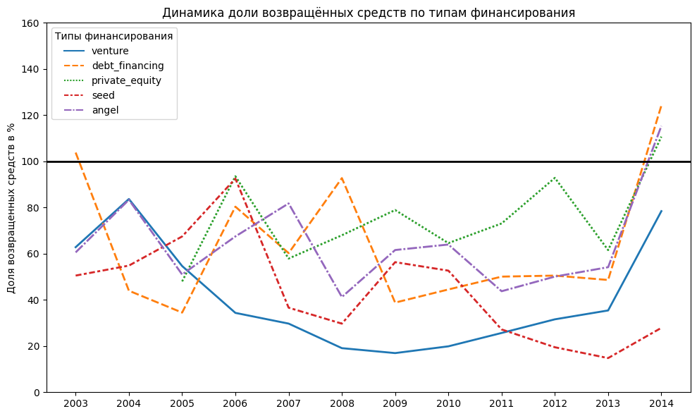

```python
# Строим линейный график
plt.figure(figsize=(10, 6))

ax = sns.lineplot(
    data=df_funding_re_table[['venture', 'debt_financing', 'private_equity', 'seed', 'angel']],
    linewidth=2,
)
# Горизонтальная линия на уровне 100%
plt.axhline(y=100, color='k', linestyle='-', linewidth=2)

# Оформление
plt.title('Динамика доли возвращённых средств по типам финансирования')
plt.ylabel('Доля возвращенных средств в %')
plt.xlabel('')
plt.ylim(0, 160)
plt.xticks(range(2003, 2015, 1))
plt.legend(title='Типы финансирования', loc='upper left')

# Оптимизируем макет
plt.tight_layout()
# Показываем график
plt.show()
```

## Шаг 5. Итоговый вывод и рекомендации

### Итоги проекта

#### Выполненные шаги

В ходе исследования были последовательно выполнены следующие этапы работы.

Загрузка и предобработка данных:

- Импортированы основные датасеты (`cb_investments.zip` и `cb_returns.csv`).
- Приведены к единому формату названия столбцов, устранены лишние пробелы и текстовые поля преобразованы в нижний регистр.
- Обработаны типы данных: столбцы с датами переведены в `datetime`, `funding_total_usd` — в числовой формат.
- Заполнены пропуски в текстовых столбцах значением `unknown`.
- Удалены полные дубликаты и строки без данных о финансировании.
- Восстановлены пропуски в `mid_funding_at` на основе `first_funding_at` и `last_funding_at`.

Инжиниринг признаков:

- Созданы группы по срокам финансирования (`единичное`, `до года`, `более года`).
- Сегменты рынка классифицированы на `массовые`, `средние` и `нишевые` по количеству компаний.
- Для анализа оставлены только массовые сегменты, остальные объединены в `mid` и `niche`.

Работа с выбросами и анализ:

- Визуализировано распределение финансирования с помощью гистограмм и диаграммы размаха.
- Определены аномальные значения финансирования методом IQR по сегментам.
- Исключены компании с аномальным финансированием (12,8 % от общего числа).
- Проанализированы типы финансирования по объёму, популярности и среднему чеку.

Анализ динамики:

- Исследована динамика среднего размера раунда и общего количества раундов по годам.
- выделены массовые сегменты с ростом финансирования в 2014 г.
- Рассчитана и визуализирована доля возвращённых средств по типам финансирования.

Итоги проекта:

- Выполненные шаги
- какие выводы удалось сделать;
- насколько выводы согласуются между собой или, наоборот, вызывают сомнения.

Представьте, что на календаре 2015 год. Опираясь на результаты анализа, дайте рекомендацию заказчику:

- в какую отрасль стоит инвестировать;
- какой тип финансирования при этом будет наиболее уместным.

#### Основные выводы

Распределение финансирования:

- Большинство сегментов — нишевые (до 35 компаний), но массовые сегменты аккумулируют наибольшую долю объема инвестиций.
- Медиана общего финансирования — около 2 млн USD, типичные значения — до 24,5 млн USD.
- Венчурные инвестиции доминируют как по объёму финансирования, так и по объему возвратов.

Типы финансирования:

- `venture` — самый объёмный и стабильный источник финансирования.
- `seed`, `angel`, `equity_crowdfunding` — частые, но с небольшими объемами инвестиций.
- `private_equity`, `post_ipo_equity`, `post_ipo_debt` — редкие, но с большими объемами инвестиций.

Динамика по годам:

- Пик среднего объема финансирования одного раунда — в 2005 г. (5,8 млн USD), затем постепенное снижение до 2,2 USD.
- Максимальное количество раундов — в 2013 г. (12 880), в 2014 г. резкое падение (до 7 124), что может быть связано с неполнотой данных за декабрь 2014 г.
- В 2014 г. рост финансирования показали сегменты: `medical`, `internet`, `apps`, `real estate`, `technology`.

Возвраты средств:

#### Согласованность выводов

Выводы в целом согласуются:

- Венчурные инвестиции — ключевой драйвер рынка, сочетающий масштаб и относительную стабильность.
- Массовые сегменты (`medical`, `internet`, `apps`, `real estate`) показывают устойчивый рост, что подтверждает их инвестиционную привлекательность.
- Аномалии в финансировании (12,8 %) не искажают общую картину, так как были корректно исключены.

Сомнения вызывает:

- Неполнота данных за декабрь 2014 г., что может повлиять на оценку динамики 2014 г.
- Высокая волатильность возвратов по некоторым типам финансирования (`private_equity`, `debt_financing`), что усложняет прогнозирование.

### Рекомендации на 2015 год

#### Отрасль для инвестирования

Приоритетные сегменты с учётом роста и объёма финансирования:

- `Medical` — стабильный рост, высокий потенциал инноваций.
- `Internet` — масштабируемость, устойчивая динамика.
- `Apps` — быстрый рост, низкая стоимость входа.
- `Real estate` — рост в 2014 г., потенциал монетизации.

Данные сегменты показали увеличение объёма финансирования в 2014 г. и обладают достаточной ликвидностью для инвесторов.

#### Тип финансирования

Оптимальный вариант — **венчурные инвестиции (`venture`)**:

#### Итог

В 2015 г. целесообразно фокусироваться на **венчурных инвестициях** в сегментах `medical`, `internet`, `apps` и `real estate`. Это сочетание обеспечивает баланс роста, ликвидности и управляемый риск.